# CHAPTER A18

# 柱および薄板の不安定性の理論

（ジョージ・リアニス博士著）

## パート1 柱の弾性および非弾性不安定性

### A18.1 はじめに

本章のパート1は、完全な弾性柱および不完全な弾性柱の不安定性の理論的取扱いに限定する。柱は、不安定現象を被る様々な種類の構造要素の中で最も単純なものである。柱について展開された理論は、薄板の不安定性の研究の基礎を形成し、その主題はパート2で扱われる。

### A18.2 柱の組合せ曲げおよび圧縮

一端が単純支持され、他端がヒンジで支持された柱（Fig. A18.1）が、圧縮荷重 $P$ と横荷重 $Q$ の同時作用を受けている場合を考える。荷重 $P$ がない場合、 $Q$ による曲げモーメントは以下のようになる。

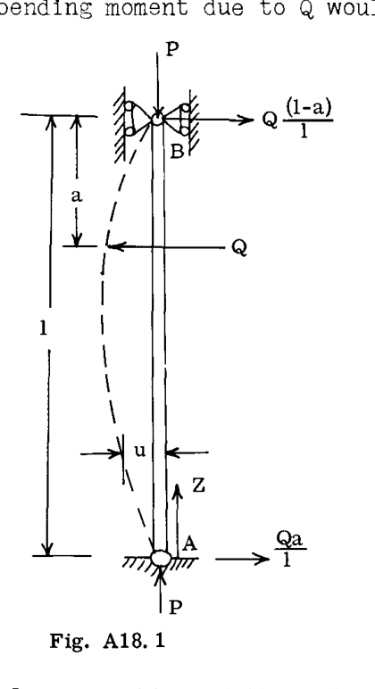

Fig. A18.1

柱の下部において

$$M_1 = \frac{Qaz}{l} \quad \text{--- (a)}$$

柱の上部において

$$M_1^1 = \frac{Q(l-a)(l-z)}{l} \quad \text{--- (b)}$$

たわみ $u(z)$ により、軸荷重 $P$ は曲げモーメントに以下の量だけ寄与する。

$$M_2 = Pu \quad \text{--- (c)}$$

したがって、断面 $z$ における全曲げモーメントは以下のようになる。

$$M = Pu + \frac{Qaz}{l} \quad \text{--- (d)}$$

$$M = Pu + \frac{Q(l-a)(l-z)}{l} \quad \text{--- (e)}$$

単純曲げの力学から、たわみ方程式は以下のようになる。

$$\frac{d^2u}{dz^2} = - \frac{M}{EI_y} \quad \text{--- (1)}$$

したがって、柱のたわみ $u(z)$ は、

$$EI \frac{d^2u}{dz^2} = - Pu - \frac{Qaz}{l} , \quad (0 \le z \le 1-a)$$

$$EI \frac{d^2u}{dz^2} = - Pu - Q \frac{(l-a)(l-z)}{l} , \quad (1-a \le z \le 1) \quad \text{--- (2)}$$

ここで、記号

$$\frac{P}{EI} = K^2 \quad \text{--- (3)}$$

を導入すると、式 (2) の一般解は以下のようになる。

$$u = C_1 \cos Kz + C_2 \sin Kz - \frac{Qaz}{Pl} , \quad (0 \le z \le l-a) \quad \text{--- (4a)}$$

$$u = C_3 \cos Kz + C_4 \sin Kz - Q \frac{(l-a)(l-z)}{Pl} , \quad (1-a \le z \le 1) \quad \text{--- (4b)}$$

ここで、 $C_1$ , $C_2$ , $C_3$ , および $C_4$ は境界条件から決定される積分定数である。

式 (4) について、 $z=0$ および $z=l$ で $u=0$ であるため、以下が成り立つ。

$$C_1 = 0 \quad \text{and} \quad C_3 = - C_4 \tan Kl \quad \text{--- (f)}$$

$z = (1-a)$ において、(4a) と (4b) でそれぞれ与えられるたわみ曲線の2つの部分は、同じたわみと傾きを持たなければならない。これら2つの条件から、 $C_2$ と $C_4$ を決定する。

$$C_2 = \frac{Q \sin Ka}{PK \sin Kl} , \quad C_4 = - \frac{Q \sin K(l-a)}{PK \tan Kl} \quad \text{--- (g)}$$

$$u = \frac{Q \sin Ka}{PK \sin Kl} \sin Kz - \frac{Qaz}{Pl} , \quad (0 \le z \le l-a) \quad \text{--- (5a)}$$

$$u = \frac{Q \sin K(l-a)}{PK \sin Kl} \sin K(l-z) - \frac{Q(l-a)(l-z)}{Pl} , \quad (1-a \le z \le l) \quad \text{--- (5b)}$$

荷重 $Q$ が柱の中央に作用する場合、最大たわみは以下のようになる。

$$u_{\text{max}} = \frac{Q \tan \frac{Kl}{2}}{2PK} - \frac{Ql}{4P} \quad \text{--- (6)}$$

$\frac{Kl}{2} = \frac{\pi}{2}$ に対して、 $\tan \frac{Kl}{2} \to \infty$ となることは明らかである。したがって、 $Kl = \pi$ のとき柱の最大たわみは無限大になり、式 (3) から以下のようになる。

$$P_{\text{cr}} = \frac{\pi^2 EI}{l^2} \quad \text{--- (7)}$$

式 (7) は、オイラーによって最初に導出された重要な方程式である。これは、柱に無限のたわみを生じさせる臨界圧縮荷重を与え、圧縮における柱の極限強度を規定する。

式 (7) から、オイラーの臨界荷重は横荷重 $Q$ の大きさとは無関係であることが明らかである。したがって、横荷重 $Q$ が存在しない場合でも、式 (7) で与えられる圧縮荷重のみの作用下で最大たわみが無限大になるように思われる。

### A18.3 柱の弾性安定性

臨界荷重に関する上記の結論は、純粋に数学的な推論に基づいていた。我々は、無限のたわみを引き起こす圧縮荷重の臨界値を見出した。

しかし、はるかに重要なのは、物理的な議論に基づくべき柱の安定性の調査である。荷重 $P$ が式 (7) で与えられる臨界値に達する前に何が起こるのか、また、この臨界値を超えた場合に柱がどのように動作するのかという疑問が生じる。

弾性系は、与えられた荷重の下で、その物体に微小な荷重が加わっても変位に微小な変化しか生じず、加えた荷重を取り除くと物体が元に戻る場合、**安定**と呼ばれる。荷重をほとんど、またはまったく増加させずとも変位が連続的に増加する場合、系は**不安定**である。妨害を取り除いた後も物体が変位した位置にとどまる場合、その物体は**中立平衡**にあると言われる。これらの定義を踏まえて、臨界荷重に達する前と達した後の柱の挙動を調査する。

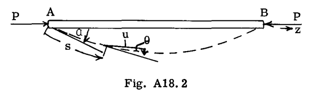

Fig. A18.2

Fig. A18.2 に示すように、軸荷重 $P$ を受けた単純支持柱が小さな妨害によって曲げられていると仮定する。たわんだ軸に沿った距離 $s$ におけるたわみが $u$ である場合、 $P$ による曲げモーメントは $Pu$ である。

曲げの工学理論から、以下がわかっている。

$$\frac{EI}{R} = -M$$

したがって、

$$\frac{EI}{R} = -Pu \quad \text{--- (8a)}$$

中立軸の曲率の正確な表現は以下の通りである。

$$\frac{1}{R} = \frac{d\theta}{ds}$$

ここで、 $s$ は変形した軸の弧長であり、 $\theta$ は曲線への接線と $z$ 軸との間の角度である。したがって、

$$EI \frac{d\theta}{ds} + Pu = 0 \quad \text{--- (8b)}$$

(8b) を $s$ について微分し、 $\frac{du}{ds} = \sin \theta$ であるため、以下を得る。

$$EI \frac{d^2\theta}{ds^2} + P \sin \theta = 0 \quad \text{--- (8c)}$$

(8c) に $d\theta$ を掛け、

$$\frac{d^2\theta}{ds^2} d\theta = \frac{d\theta}{ds} d\left(\frac{d\theta}{ds}\right)$$

であることに注意して積分すると、

$$EI \frac{d\theta}{ds} d\left(\frac{d\theta}{ds}\right) + P \int \sin \theta d\theta = C$$

または、

$$\frac{EI}{2} \left(\frac{d\theta}{ds}\right)^2 - P \cos \theta = C \quad \text{--- (8d)}$$

端部 $A$ において $\theta = -\alpha$ および $M = EI \frac{d\theta}{ds} = 0$ であるため、 $C = - P \cos \alpha$ であることがわかる。

ここで、 $k = \sqrt{\frac{P}{EI}}$ とする。 — (8e)

すると、式 (8d) は次のようになる。

$$\frac{1}{\sqrt{2}} \frac{d\theta}{ds} = k \sqrt{\cos \theta -
\cos \alpha}$$

または、

$$ds = \frac{d\theta}{\sqrt{2} k \sqrt{\cos \theta - \cos \alpha}} \quad \text{--- (8f)}$$

たわんだ形状における柱の全長さは、以下で与えられる。

$$l = \int_A^B ds = \int_{-\alpha}^{\alpha} \frac{d\theta}{\sqrt{2} k \sqrt{\cos \theta - \cos \alpha}} \quad \text{--- (8h)}$$

または、

$$l = \int_{-\alpha}^{\alpha} \frac{d\theta}{2k \sqrt{\sin^2 \frac{\alpha}{2} - \sin^2 \frac{\theta}{2}}} \quad \text{--- (8i)}$$

$\sin \frac{\alpha}{2}$ を $p$ と表し、新しい変数 $\phi$ を導入する。

$$\sin \frac{\theta}{2} = p \sin \phi$$

すると、式 (8i) は次のようになる。

$$l = \frac{2}{k} \int_0^{\frac{\pi}{2}} \frac{d\phi}{\sqrt{1 - p^2 \sin^2 \phi}} = \frac{2K}{k} \quad \text{--- (8j)}$$

ここで、

$$K = \int_0^{\frac{\pi}{2}} \frac{d\phi}{\sqrt{1 - p^2 \sin^2 \phi}}$$

は第一種完全楕円積分と呼ばれ、表から見つけることができる。 $\alpha$ 、したがって $p$ が非常に小さい場合、式 (8j) において $p^2 \sin^2 \phi$ は無視することができ、その結果、

$$l = \frac{2}{k} \int_0^{\frac{\pi}{2}} d\phi = \frac{\pi}{k} = \pi \sqrt{\frac{EI}{P}}$$

これより、

$$P = \frac{\pi^2 EI}{l^2} \quad \text{--- (8k)}$$

柱の中点におけるたわみは次のようになる： $\theta = 0$ 、 $du = ds \sin \theta$ 、そして式 (8f) から、

$$u\left(z = \frac{l}{2}\right) = \delta = \frac{1}{2k} \int_{-\alpha}^{\alpha} \frac{\sin \theta d\theta}{\sqrt{\sin^2 \frac{\alpha}{2} - \sin^2 \frac{\theta}{2}}} \quad \text{--- (8l)}$$

または $\phi$ で表すと、

$$\delta = \frac{2p}{k} \int_0^{\frac{\pi}{2}} \sin \phi d\phi = \frac{2p}{k} \quad \text{--- (8m)}$$

式 (8j) と式 (8k) から、次式を得る。

$$\frac{P}{P_{\text{cr}}} = \frac{Pl^2}{\pi^2 EI} = \frac{4K^2}{\pi^2} \quad \text{--- (8n)}$$

$$\frac{\delta}{l} = \frac{2p}{\pi \sqrt{\frac{P}{P_{\text{cr}}}}} \quad \text{--- (8o)}$$

ここで、中点における曲げモーメント $M = P\delta$ を無次元形式で書いてみよう。

$$m = \frac{P}{P_{\text{cr}}} \cdot \frac{\delta}{l} = \frac{4KP}{\pi^2} \quad \text{--- (8p)}$$

$p = \sin \frac{\alpha}{2}$ は $\alpha$ の関数であるため、楕円積分 $K$ も同様であり、比率 $\frac{P}{P_{\text{cr}}}$ および $\frac{\delta}{l}$ は式 (8n) と (8o) から計算される。

したがって、 $\frac{P}{P_{\text{cr}}}$ は $\frac{\delta}{l}$ の関数であり、楕円積分を与える表を用いて計算される。したがって、Fig. A18.3 に示すように、 $m$ を $\delta/l$ に対してプロットすることができる。

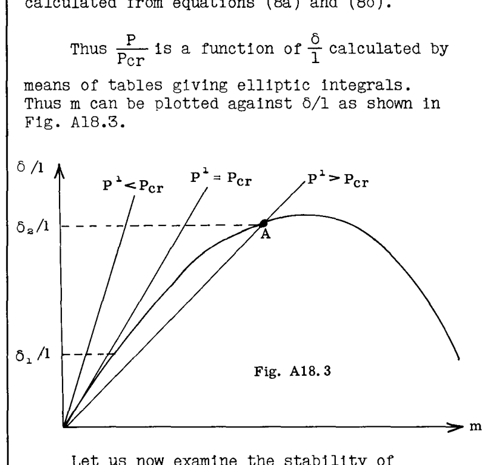

Fig. A18.3

次に、様々な平衡構成の安定性を調べてみよう。荷重 $P^1$ が柱に作用しており、柱が特定の最大たわみ $\delta$ を持っていると仮定する。ここで、 $P^1$ は $\delta$ に対応していないとする。

$m^1$ 対 $\delta/l$ の曲線は直線である。 $m = m^1$ である場合、すなわち $m^1(\delta/l)$ 曲線が $m(\delta/l)$ 曲線と交差する場合、柱は平衡状態にある。

ここで、 $\delta = 0$ において、柱が小さな妨害によって変位し、たわみ $\delta_1$ を得ると仮定する。 $P^1 < P_{\text{cr}}$ の場合、Fig. A18.3 から $m > m^1$ であることがわかる。したがって、 $P^1$ は曲がった形状で柱を平衡に維持するのに十分ではなく、柱は直線の形状に戻る。したがって、 $P^1 < P_{\text{cr}}$ に対しては、直線の形状が安定である。

$P^1 > P_{\text{cr}}$ の場合、 $m^1 > m$ となる。したがって、 $m^1$ は柱をさらに曲げることになる。これは、 $P^1 > P_{\text{cr}}$ の場合、直線の平衡形式が不安定であることを意味する。柱は、 $m^1$ が $m$ と等しくなるまで（Fig. A18.3 の点A）曲がり続ける。柱が A からさらに変位した場合、たわみは $\delta_2$ よりも大きくなり、新しい位置では $m > m^1$ となる。柱は点 A に跳ね戻る。したがって、点 A は安定である。

$P = P_{\text{cr}}$ において、 $m^1$ 対 $\delta/l$ の直線は原点で $m$ 曲線に接する。したがって、微小な妨害に対して、そのような小さな妨害では $m^1$ は $m$ と等しいままであるため、柱は変位した位置で平衡状態を維持する。したがって、柱は中立平衡状態にある。

### A18.4 圧縮による柱の破壊

前節で柱の安定性について議論した際、臨界オイラー荷重（式 7）未満では直線形状が安定であり、 $P_{\text{cr}}$ を超えると曲がった形状が安定であり、 $P_{\text{cr}}$ では平衡が中立であることが示された。Fig. A18.4 に示すように $P/P_{\text{cr}}$ 対 $\delta/l$ の曲線をプロットすることにより、以下の挙動が観察される。

1. $P/P_{\text{cr}} < 1$ 未満では、平衡位置は $\delta/l = 0$ の1つだけである。

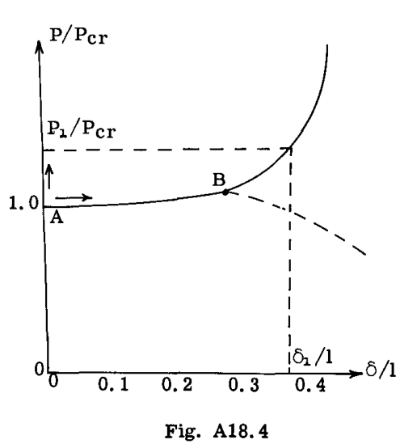

Fig. A18.4

曲線 BD の上昇部分は、材料が弾性的に振る舞う限り保持される。しかし、曲線のほぼ平坦な部分の内側のある点 B において、柱の内側繊維は降伏応力に等しい最大応力を獲得する。その後の挙動の弾塑性解析を行うと、曲線がほぼ即座に低下することが観察される。やはり、この最大荷重 $P_B$ はオイラー荷重に非常に近い。したがって、設計目的のために、座屈荷重であるオイラー荷重は、柱が支持できる極限荷重の非常に優れた近似値である。

別の議論が上記の結論を裏付ける。前段落で柱の座屈について議論した際、柱は最初は直線であり、中心に荷重がかけられ、均質な材料で作られていると仮定した。しかし、実際の柱は、初期の曲がり（例えば、製造における不可避の許容誤差による）、わずかな荷重の偏心、および完全な均質性の欠如のために不完全である。したがって、小さな荷重であっても、常にある程度の曲げが存在する。

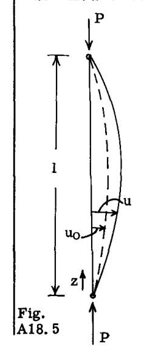

Fig. A18.5

ここで、柱軸の特定の初期たわみ $u_0$ （Fig. A18.5 参照）を仮定することにより、このような初期に不完全な柱の挙動を調べてみよう。小さなたわみに対して、その後の曲げ（荷重後）による曲率の変化は以下の通りである。

$$\delta\left(\frac{1}{R}\right) = \frac{d^2u}{dz^2} - \frac{d^2u_0}{dz^2}$$

たわみの微分方程式において、 $1/R$ は、初期の直線柱に対して曲率そのものと一致する曲率の変化であることを証明できる。したがって、曲げモーメントが $Pu$ である本ケースでは、たわみの方程式は次のようになる。

$$\frac{d^2u}{dz^2} - \frac{d^2u_0}{dz^2} = - k^2u \quad \text{--- (9)}$$

$u_0$ をフーリエ級数で表してみよう。

$$u_0 = \sum_{1}^{\infty} \delta_n \sin \frac{n\pi z}{l} \quad \text{--- (10)}$$

$$u = \sum_{n=1}^{\infty} \delta_n \sin \frac{n\pi z}{l} \quad \text{--- (11a)}$$

ここで、

$$\delta_n = \frac{\bar{\delta}_n}{1 - P/P_n} \quad \text{--- (11b)}$$

$$P_n = \frac{n^2 \pi^2 EI}{l^2}$$

中央における柱のたわみは以下の通りである。

$$\delta_{\text{max}} = \delta_1 - \delta_3 + \delta_5 - \cdots \quad \text{--- (12)}$$

たわみ対荷重をプロットすると、曲線（Fig. A18.6）が得られ、これは漸近的に水平線 $P/P_{\text{cr}} = 1$ に近づく。しかし、この曲線は、近似

$$\delta\left(\frac{1}{R}\right) \approx \frac{d^2u}{dz^2} - \frac{d^2u_0}{dz^2}$$

が有効である小さなたわみに対してのみ有効である。

前段落と同様の処理により、大きなたわみに対しては、荷重たわみ曲線が点 I（曲線 FIH）の後に上昇することがわかる。塑性の開始により、実際の曲線は点 $I^1$ （曲線 $F I I^1 H^1$ ）で低下する。 $I^1$ における破壊荷重は、 $P_{\text{cr}}$ よりも大きくも小さくもなり得るが、通常はそれに非常に近い。

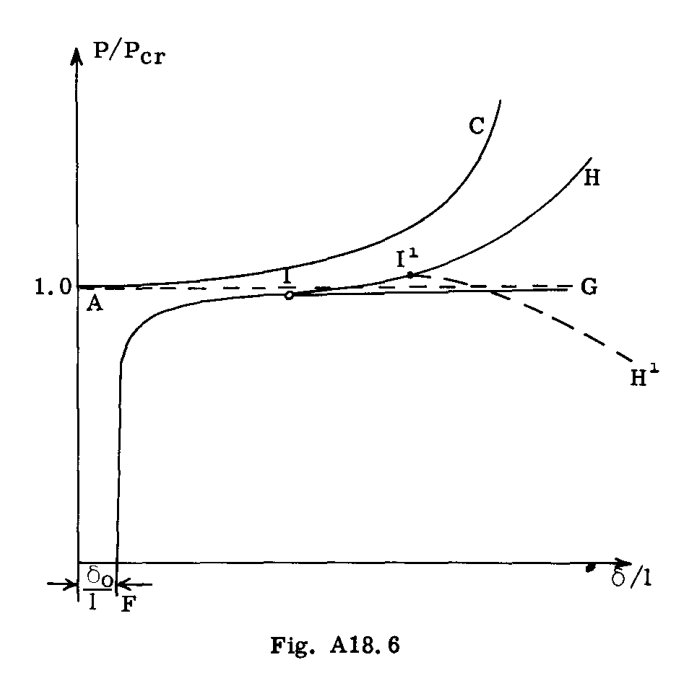

Fig. A18.6

以上の議論において、実用的なすべての目的において、オイラー座屈荷重は、実際の柱または実用的な柱が支持できる極限荷重と見なすことができることを示した。実際の極限荷重に近いことに加えて、臨界荷重は、初期の不完全さや塑性効果を含む長時間の計算を行う必要なく、式 (7) から容易に計算できる。

ただし、式 (7) で与えられる座屈荷重は、圧縮荷重による均一応力（ $\sigma = P/A$ 、ここで $A$ は断面積）が降伏応力未満である場合に有効であることに注意する必要がある。 $\sigma$ が降伏応力よりも高い場合、塑性理論は座屈荷重に対して別の値を予測する。ここで式 (11) を参照すると、以下が得られる。

$$P_n = n^2 P_{\text{cr}} \quad (P_{\text{cr}} \text{ は式 7 から})$$

$$\delta_n = \frac{\bar{\delta}_n}{1 - \frac{P}{n^2 P_{\text{cr}}}}$$

したがって、 $P$ が $P_{\text{cr}}$ に近づくにつれて、以下がわかる。

$$\frac{\delta_1}{\bar{\delta}_1} \to \infty, \quad \frac{\delta_2}{\bar{\delta}_2} \to \frac{4}{3}, \quad \frac{\delta_3}{\bar{\delta}_3} \to 9/8 \quad \text{etc.}$$

したがって、 $\delta_1 \gg \delta_2 \gg \delta_3$ であり、かつ：

$$\delta_{\text{max}} \approx \delta_1 = \frac{\bar{\delta}_1}{1 - P/P_{\text{cr}}}$$

座屈試験では、 $\delta = \delta_{\text{max}} - \bar{\delta}$ を測定する。ここで $\bar{\delta}$ は中点における初期たわみである。したがって：

$$\delta \approx \delta_{\text{max}} - \bar{\delta}_1 = \frac{\bar{\delta}_1}{\frac{P_{\text{cr}}}{P} - 1} \quad \text{and,}$$

$$P_{\text{cr}} \frac{\delta}{P} - \delta = \bar{\delta}_1 \quad \text{--- (13)}$$

座屈試験において $\delta/P$ 対 $\delta$ をプロットすると、初期たわみ $\bar{\delta}_1$ を知ることなく、実験的に臨界荷重を得ることができる。それは単にこの曲線の傾きの逆数である。

### A18.5 様々な端部条件を持つ柱の座屈荷重

前述の議論から得られた結論から、座屈問題は、初期に直線の柱の不安定性問題として考えることができる。したがって、直線形状の近くに変形した位置を別の可能な平衡形式として仮定し、直線以外の形状が可能となる荷重を求める。さらに、小さなたわみ解析のみが必要である。

曲げ座屈の一般微分方程式は以下の通りである。

$$\frac{d^4u}{dz^4} + k^2 \frac{d^2u}{dz^2} = 0 \quad \text{--- (14)}$$

そして一般解は以下の通りである。

$$u = C_1 \sin Kz + C_2 \cos Kz + C_3 z + C_4 \quad \text{--- (15)}$$

係数 $C_1$ 、 $C_2$ 、 $C_3$ 、および $C_4$ は端部支持の条件に依存する。様々な端部条件は以下の通りである。

自由端：

$$\frac{d^2u}{dz^2} = 0, \quad \frac{d^3u}{dz^3} = 0$$

ピン支持端：

$$u = 0, \quad \frac{d^2u}{dz^2} = 0$$

固定端：

$$u = 0, \quad \frac{du}{dz} = 0$$

したがって、4つの端部条件が存在する。これらは4つの線形同次方程式のシステムを与える。これらの自明な解はゼロ解である。しかし、座屈状態においては、 $C_1$ 、 $C_2$ 、 $C_3$ 、 $C_4$ はすべてゼロではない。上記システムの非ゼロ解の条件は、 $C_1$ 、 $C_2$ 、 $C_3$ 、 $C_4$ の係数の行列式がゼロに等しいことである。この方程式から、座屈荷重を計算する。

例えば、両端が単純支持された梁（両端で $u = 0, \frac{d^2u}{dz^2} = 0$ ）では、端部条件から以下が得られる。

$$C_2 + C_4 = 0, \quad C_2 = 0$$

$$C_1 \sin Kl + C_2 \cos Kl + C_3 l + C_4 = 0$$

座屈のためには、以下を持たなければならない。

$$\begin{vmatrix}
0 & 1 & 0 & 1 \\
0 & 1 & 0 & 0 \\
\sin Kl & \cos Kl & l & 1 \\
- \sin Kl & - \cos Kl & 0 & 0
\end{vmatrix} = 0$$

または $\sin Kl = 0$ または $Kl = n\pi \ (n = 1, 2, 3 \cdots)$

これより、

$$P_n = \frac{n^2 \pi^2 EI}{l^2} \quad \text{--- (16a)}$$

したがって、式 (16a) の右辺に等しい $P_n$ に対して、曲がった形状の平衡の可能な形式が存在する。 $P_n$ の最小値は $n = 1$ のときに発生し、これが座屈荷重である。

$$P_{\text{cr}} = \frac{\pi^2 EI}{l^2} \quad \text{--- (16b)}$$

他の端部条件に対する座屈荷重も同様の方法で導出できる。

## 非弾性柱の強度

### A18.6 非弾性座屈。はじめに

オイラーの座屈理論は、柱内の応力が柱材料の弾性限界をどこでも超えない限り有効である。完全な弾性柱と不完全な弾性柱の解析が同じ結果、すなわち式 (7) につながることを見てきた。

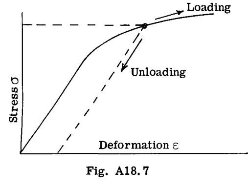

Fig. A18.7

### A18.7 完全な柱。減少弾性係数理論

完全な柱が最初に共通の応力 $\sigma$ まで均一に圧縮されると仮定する。不安定になる $\sigma$ の臨界値 $\sigma_{\text{cr}}$ を調べるために、以下を仮定する。

1. 変位が十分に小さく、曲率半径 $R$ と弾性軸のたわみ $u$ との関係が以下であること。

$$\frac{1}{R} = \frac{d^2u}{dz^2} \quad \text{--- (17a)}$$

2. 平面断面は平面を維持するため、曲げ平面上の距離 $h$ における曲げによるひずみの変化は以下であること。

$$\delta\epsilon = \frac{h}{R} = h \frac{d^2u}{dz^2} \quad \text{--- (17b)}$$

3. 応力-ひずみ関係は、材料の単純引張曲線に従うこと。
4. 曲げ平面は、断面の対称面であること。

ここで、Fig. A18.8a に示すような断面を持つ柱が塑性応力範囲内で圧縮され、不安定前の圧縮応力が $\sigma$ であると仮定する。座屈の条件を考慮するために、柱を横方向にわずかにたわませる。柱の一方の側の応力は、応力-ひずみ曲線に従う曲げのために増加するが、他方の側の応力は減少し、したがって Fig. A18.8b に示す除荷弾性線に従う。

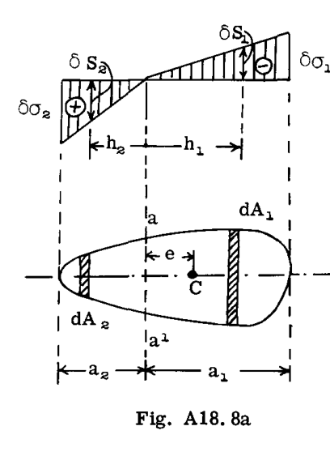

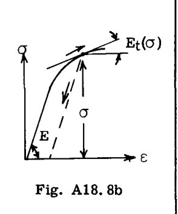

第一の側における応力の小さな変化に対して、応力の変化はひずみの変化と以下の関係にある。

$$\delta \sigma_1 = E_t(\sigma) \delta \epsilon_1 \quad \text{--- (18)}$$

ここで $E_t(\sigma)$ は応力 $\sigma$ における応力-ひずみ曲線の接線係数（Tangent Modulus）である。第二の側では、変化は弾性関係に従う、すなわち、

$$\delta \sigma_2 = E \delta \epsilon_2 \quad \text{--- (19)}$$

曲げによる圧縮（ $-$ ）応力と引張（ $+$ ）応力の分布を Fig. A18.8a に示す。応力は、図心 $c$ から距離 $e$ にある線 ( $a a^1$ ) 上でゼロになる。断面上の応力の平衡のために、以下を得る。

$$- \int_0^{a_1} \delta \sigma_1 dA + \int_0^{a_2} \delta \sigma_2 dA = 0 \quad \text{--- (20)}$$

そして、モーメントの平衡のために、

$$- \int_0^{a_1} \delta \sigma_1 (h_1 + e) dA + \int_0^{a_2} \delta \sigma_2 (h_2 - e) dA = Pu \quad \text{--- (21)}$$

応力の線形分布により、以下が得られる。

$$\delta \sigma_1 = \frac{\delta \sigma_{11}}{a_1} h_1$$

$$\delta \sigma_2 = \frac{\delta \sigma_{22}}{a_2} h_2 \quad \text{--- (22)}$$

ここで、(17b)、(18)、(19)、および (22) を方程式 (20) に代入すると、以下を得る。

$$- E_t Q_1 + E Q_2 = 0 \quad \text{--- (23)}$$

ここで、

$$Q_1 = \int_0^{a_1} h_1 dA, \quad Q_2 = \int_0^{a_2} h_2 dA \quad \text{--- (24)}$$

は線 ( $a a^1$ ) の右側および左側の断面積のモーメントである。

式 (21) から、以下を得る。

$$\bar{E} I \frac{d^2u}{dz^2} = Pu \quad \text{--- (25)}$$

ここで、

$$\bar{E} = \frac{E I_1 + E_t I_2}{I} \quad \text{--- (26)}$$

$\bar{E}$ は、いわゆる減少弾性係数（Reduced Modulus）であり、 $I_1$ と $I_2$ は両側の慣性モーメントである。

軸応力に関する中立軸の位置は式 (24) で与えられるが、座屈式 (25) は弾性座屈式 (14) に類似していることが観察される。しかし、ここでの $K$ の値は式 (3) ではなく、以下で与えられる。

$$K = \sqrt{\frac{P}{\bar{E}I}} \quad \text{--- (27)}$$

したがって、前述の解析のすべての結果は、非弾性座屈のケースにも有効である。例えば、単純支持された柱に対しては、式 (7) に従い、以下のようになる。

$$\sigma_{\text{cr}} = \frac{\pi^2 \bar{E} I}{A l^2} \quad \text{--- (28)}$$

$\bar{E}$ は式 (28) で与えられる $\sigma_{\text{cr}}$ の関数であり、未知の $\sigma_{\text{cr}}$ における $E_t$ の値であるため、臨界応力の計算には、方程式 (23)、(26)、および (28) の試行錯誤による同時解法が必要である。

### A18.8 不完全な柱。接線係数理論

もともとエンゲッサーによって提案された接線係数理論（Ref. 1）は、臨界状態において応力の逆転（除荷）が起こらず、したがって臨界応力は接線係数 $E_t$ のみによって決定されるという仮定に基づいている。この理論は、不安定性の古典的な定義（完全な柱、平衡の分岐）においてひずみの逆転が実際に発生するため、初期には放棄された。しかし近年、この接線係数理論が有用であることが証明されている。

ひずみの逆転がないという仮定の下では、Fig. A18.8a の断面の両側が、接線係数 $E_t$ に対応する同じ線形応力分布によって特徴付けられる。したがって、座屈方程式は以下のようになる。

$$E_t I \frac{d^2u}{dz^2} + Pu = 0 \quad \text{--- (29)}$$

そして、単純支持端条件に対する臨界応力は以下のようになる。

$$\sigma_t = \frac{\pi^2 E_t I}{A l^2} \quad \text{--- (30)}$$

$$\bar{E} > E_t \quad \text{and} \quad \sigma_r > \sigma_t \quad \text{--- (31)}$$

したがって、接線係数理論によって予測される臨界応力 $\sigma_t$ は、減少弾性係数理論からの $\sigma_r$ よりも小さい。完全な柱の場合、ひずみの逆転がないという仮定は塑性範囲における材料の挙動と矛盾するが、ほとんどの実験は接線係数理論による結果に極めて近い結果を与えている。

この矛盾を解決するために、シャンリー（Ref. 2）は以下の説明を提案した。簡単のために、Fig. A18.9 に示すように、中央の塑性ヒンジによって結合された2つの剛な脚によって形成される2フランジ座屈柱を考える。この柱は $\sigma_t$ に達するとすぐに座屈し始めると仮定する。

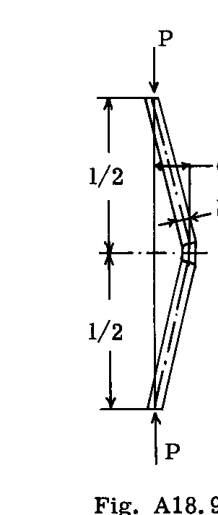

Fig. A18.9

接線係数に対応する臨界荷重 $P_t$ を超える荷重 $P$ の影響を考慮することにより、シャンリーは以下の関係を証明している。

$$P = P_t \left(1 + \frac{1}{\frac{b}{2d} + \frac{1+\tau}{1-\tau}}\right) \quad \text{--- (32)}$$

ここで、

$$\tau = E_t/E$$

座屈した構成は、改良されたオイラー理論で考慮されたものと同様に安定したものであることを強調しなければならない。シャンリーは、接線係数荷重を超えた後も、そのような安定した構成が存在し得るという事実を認識した。

$R = P/P_t$ とすると、シャンリーは、曲げによる応力の変化と、 $\sigma_t$ に対応する圧縮ひずみ $\epsilon_t$ との関係が以下のようになることを見出した。

凹側：

$$\frac{\delta\epsilon_1}{\epsilon_t} = \frac{2\left(\frac{1}{\tau} - R\right)}{\frac{1-\tau}{R-1} - (1+\tau)} \quad \text{--- (33)}$$

凸側：

$$\frac{\delta\epsilon_2}{\epsilon_t} = \frac{2(R-1)}{\frac{1-\tau}{R-1} - (1+\tau)}$$

Fig. A18.10 において、 $\tau = 0.75$ に対して $\delta\epsilon_1/\epsilon_t$ および $\delta\epsilon_2/\epsilon_t$ が $R$ に対してプロットされている。凹側のひずみは非常に急速に増加し、減少弾性係数荷重で無限の値に達するが、凸側のひずみは最初は非常にゆっくりと減少することが観察される。この図から、初期の不完全さを持つ実際の柱では、圧縮ひずみがより急速に増加することが想像できる。さらに、 $\delta\epsilon_1$ の急速な増加は $E_t$ の急速な低下を引き起こす。したがって、柱は接線係数がわずかに増加した後にその有用性を失う。したがって、接線係数理論は、実際に不安定な構成を定義するわけではないが、可能な座屈構成のスペクトルの下限を表し、その上限は無限のたわみに対応する減少弾性係数荷重である。

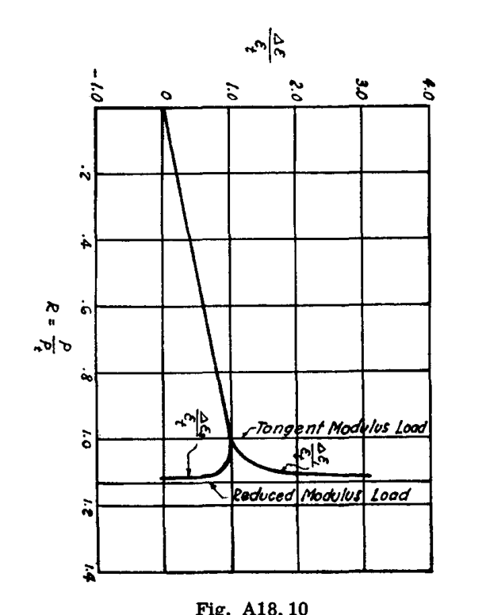

Fig. A18.10

要約すると、非弾性範囲における柱の破壊応力は、オイラーの方程式において $E$ を接線係数 $E_t$ に置き換えることによって求められることを示すのに十分な実験結果が存在する。すなわち、

$$\sigma_{\text{cr}} = \frac{\pi^2 E_t}{(L/r)^2}, \quad r = \sqrt{\frac{I}{A}} \quad \text{--- (34)}$$

Fig. A18.11 および 12 は、接線係数 $E_t$ を用いたオイラー方程式によって与えられる強度を実験結果がどのように検証しているかを示している。

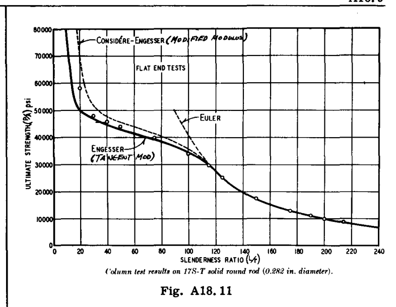

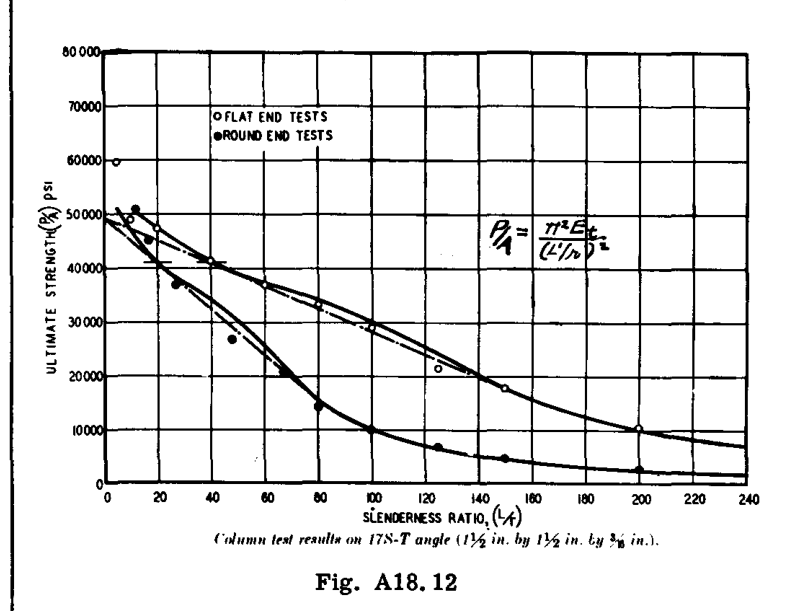

### 参考文献

- **Ref. 1.** Engesser F., Schweizerische Bauzeitung. Vol. 26, p. 24, 1895.
- **Ref. 2.** Shanley, F.R., Inelastic Column Theory, Jour. Aeronautical Sciences, 1947, p. 261.